# A Visualisation of the Derivative.

Toby Hayward

4/16/2022

Any calculus student encounters the derivative for the first time in their 3<sup>rd</sup> to 2<sup>nd</sup> to last year of high school. They’ll learn that the derivative of a function is the rate of change at an instant in time, or graphically, the slope tangent line to the curve plotted by a function $f(x)$.  
They’ll learn that the derivative is a function which gives this number, given a point $x$, and that we can derive this equation through applying a series of rules such as the *Power Rule*, *Chain Rule*, *Quotient Rule*, or by simply remembering the corresponding derivative equation $f'(x)$ of $f(x)$ such as $\frac{d}{dx} sin(x) = cos(x)$.

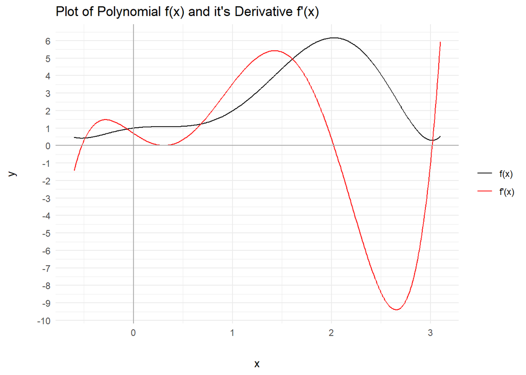

## The problem.

Unfortunately for a lot of students, they go through their education without understanding where the derivative first came from. How did we derive the *Power Rule* and what does an instantaneous rate of change mean?  
After studying further they’ll eventually encounter the limit definition for a derivative, and begin to understand how reducing this little distance $dx$ to an infinitesimally small length, they can derive the true tangent line at a point on the curve, and hence it’s slope.  
I propose the following visualisation of how this process works. This visualisation takes a function $f(x)$ and a distance $dx$ and estimates the tangent slope between two points on the curve $f(x)$ at a horizontal distance of $dx$. It then shows by reducing $dx$ how the function becomes a better and better approximation of the derivative function $f'(x)$, hence visualising the limit definition of a derivative.

```r
derivative_approx <- function(a, b, dx, fun) {
  # [a, b] = domain of the function
  # dx = distance between the points x1, x2 to estimate dy.
  # fun = the function f(x).
  x = seq(a, b, dx)
  y = fun(x)

  dy = vector(mode = 'double', length(x)) #Initialising a vector to insert values of x into.

  for (i in 2:((b-a)/dx + 1)) {
    dy[i] = y[i] - y[i-1]
  }

  #Approximating endpoint with cubic linear predictor.
  npred_points <- min(max(3, floor(length(x)/2)), 5)
  dy[1] <- predict(lm(data = data.frame(y = dy[2:npred_points], x = x[2:npred_points]), y ~ poly(x, npred_points - 2)), newdata = data.frame(x = x[1]))
  ans = dy/dx

  return(ans)
  #ans = sequence of estimated slopes for a given x.
}
```

```r
make_function_vis <- function(a, b, fun, ylab) {
  plot <- tibble(x = seq(a, b, (b-a)/100),
                 y = fun(x)) %>%
    ggplot(aes(x = x, y = y)) +
    geom_line() +
    labs(title = sprintf('Plot of f(x) against x where f(x) = %s', ylab),
         y = ylab) +
    theme_minimal() +
    theme(axis.title.y = element_text(margin = margin(r = 20)),
          axis.title.x = element_text(margin = margin(t = 20))) +
    geom_hline(yintercept = 0, col = 'darkgray') +
    geom_vline(xintercept = 0, col = 'darkgray')

  return(plot)
}

make_derivative_vis <- function(a, b, fun, dfun = NA, ylab) {
  if (suppressWarnings(is.na(dfun)))  base_plot.data = tibble(x = seq(a, b, (b-a)/100), actualdy = 0)
  else base_plot.data = tibble(x = seq(a, b, (b-a)/100), actualdy = dfun(x))

  base_plot = base_plot.data %>%
    ggplot(aes(x = x, y = actualdy)) +
    geom_line(col = 'red') +
    theme_minimal() +
    theme(axis.title.y = element_text(margin = margin(r = 20)),
          axis.title.x = element_text(margin = margin(t = 20))) +
    labs(title = sprintf("f'(x) and approximates against x where f(x) = %s", ylab),
         y = "f'(x)") +
    geom_hline(yintercept = 0, col = 'darkgray') +
    geom_vline(xintercept = 0, col = 'darkgray')

  for (dx in seq(0.1, 1, 0.1)) {
    temp_tib <- tibble(x = seq(a, b, dx),
                       y = derivative_approx(a, b, dx, fun))
    base_plot <- base_plot +
      geom_line(data = temp_tib, aes(x = x, y = y), alpha = 1 - dx)
  }

  # An appalling bodge of a test for no derivative function supplied.

  x = seq(a, b, (b-a)/100)

  if ((suppressWarnings(is.na(dfun)))) {
    dx = 0.01
    temp_tib <- tibble(x = seq(a, b, dx),
                       y = derivative_approx(a, b, dx, fun))
    print(temp_tib)
    base_plot <- base_plot +
      geom_line(data = temp_tib, aes(x = x, y = predict(gam(data = temp_tib, y ~ s(x)))), col = 'blue')
  }

  return(base_plot)
}
```

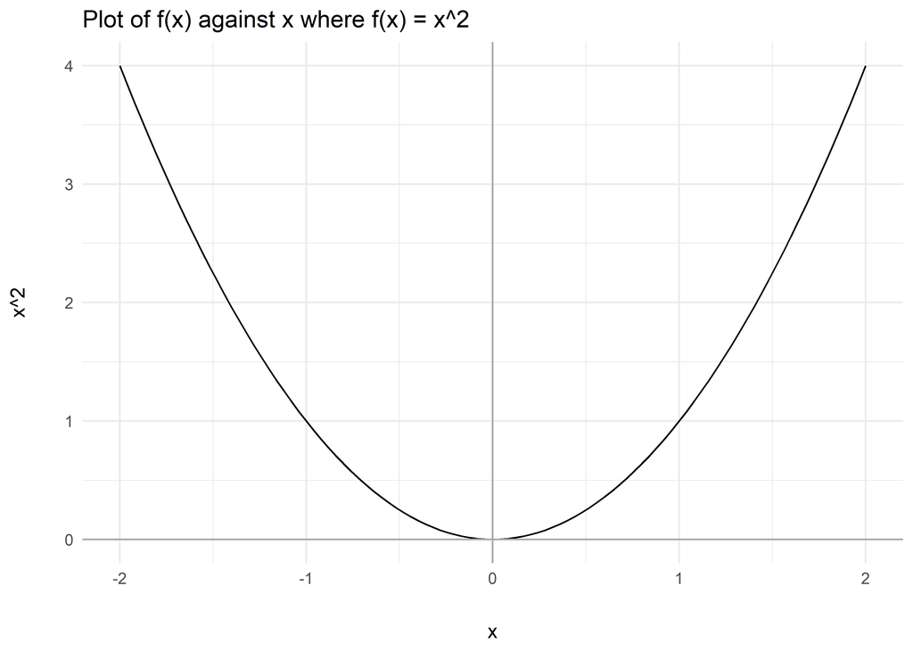

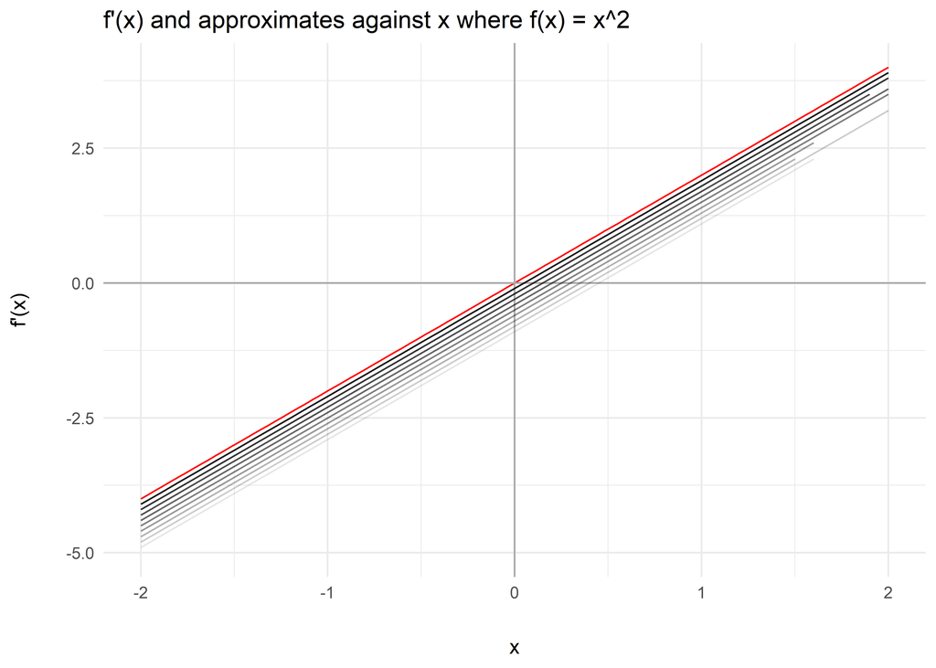

```r
f_name = 'x^2'

f <- function(x) {
  return(x^2)
}
df <- function(x) {
  return(2 * x)
}

a = -2; b = 2

p1a <- make_function_vis(a, b, f, f_name)
p1a

p1b <- make_derivative_vis(a, b, f, df, f_name)
p1b
```

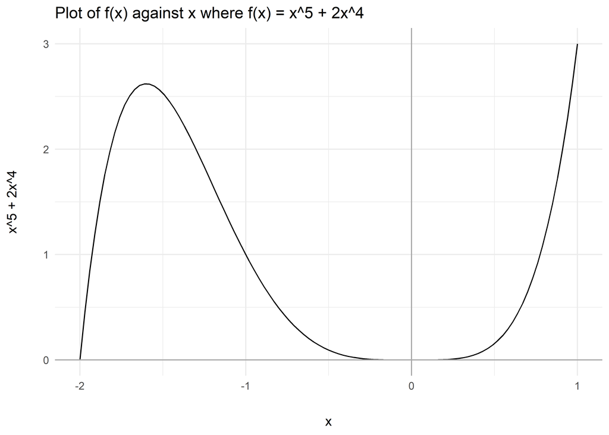

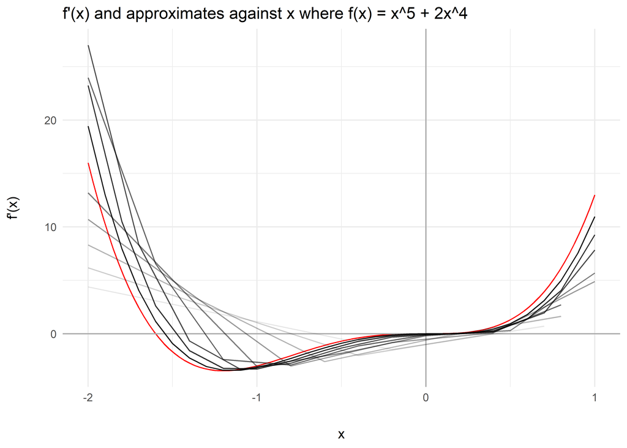

```r
f_name = 'x^5 + 2x^4'

f <- function(x) {
  return(x^5+2*x^4)
}
df <- function(x) {
  return(5 * x^4 + 8 * x^3)
}

a = -2; b = 1

p2a <- make_function_vis(a, b, f, f_name)
p2a

p2b <- make_derivative_vis(a, b, f, df, f_name)
p2b
```

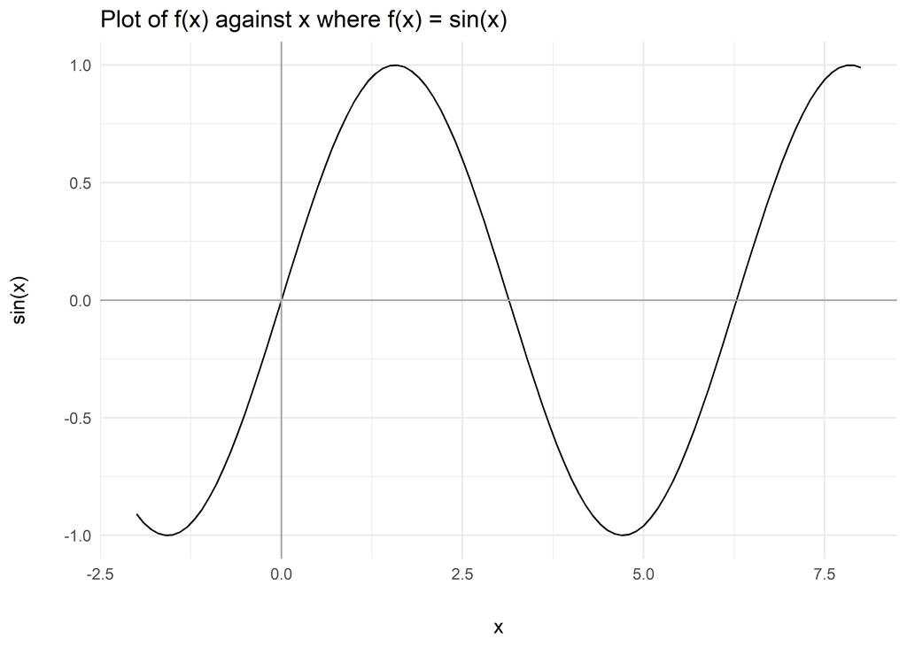

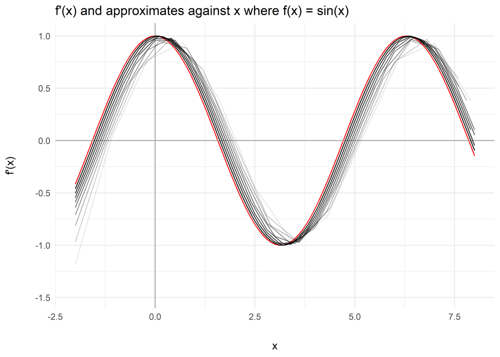

```r
f_name = 'sin(x)'

f <- function(x) {
  return(sin(x))
}
df <- function(x) {
  return(cos(x))
}

a = -2; b = 8

p3a <- make_function_vis(a, b, f, f_name)
p3a

p3b <- make_derivative_vis(a, b, f, df, f_name)
p3b
```

## An estimation of a derivative of which we do not know.

I also wanted to use this opportunity to use this algorithm to visualise complex derivatives, and then fit a smoother to create a “local” derivative function.

$$f(x) =
log(\frac{x+4}{5})\times\frac{sin(x+4)}{(x+4)^2}$$

```r
f_name = 'ln((x+4)/5)*sin(x+4)/((x+4)^2)'

f <- function(x) {
  return(log((x+4)/5)*sin(x+4)/((x+4)^2))
}

a = 0; b = 4

p4a <- make_function_vis(a, b, f, f_name)
p4a

p4b <- make_derivative_vis(a, b, f, ylab = f_name)
```

```
## # A tibble: 401 × 2
##        x        y
##    <dbl>    <dbl>
##  1  0    -0.00788
##  2  0.01 -0.00809
##  3  0.02 -0.00830
##  4  0.03 -0.00850
##  5  0.04 -0.00869
##  6  0.05 -0.00888
##  7  0.06 -0.00906
##  8  0.07 -0.00924
##  9  0.08 -0.00940
## 10  0.09 -0.00957
## # … with 391 more rows
```

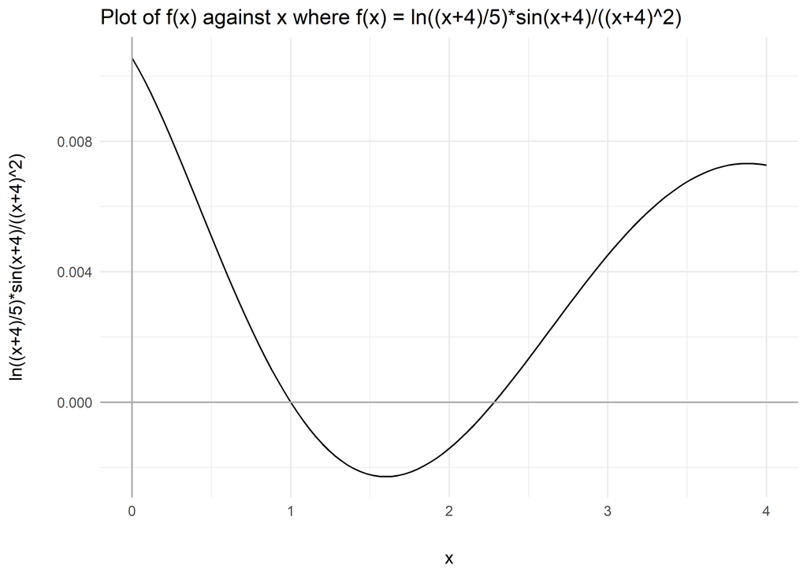

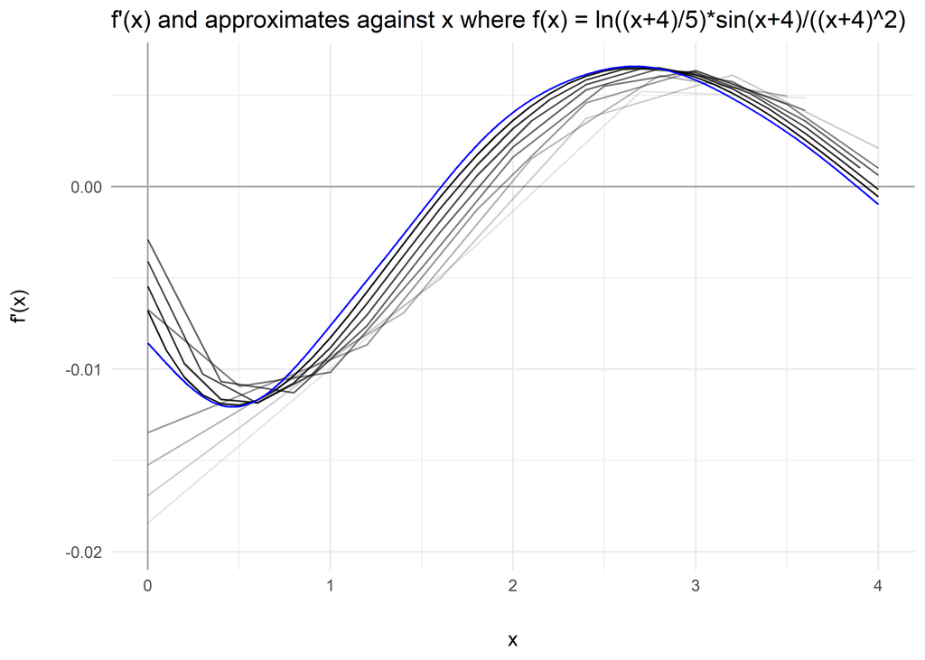

```r
p4b
```

$$f(x) = tan(sin(cos(x^2+x)))$$

```r
f_name = 'tan(sin(cos(x^2 + x)))'

f <- function(x) {
  return(tan(sin(cos(x^2 + x))))
}

a = -2; b = 3

p5a <- make_function_vis(a, b, f, f_name)
p5a

p5b <- make_derivative_vis(a, b, f, ylab = f_name)
```

```
## # A tibble: 501 × 2
##        x     y
##    <dbl> <dbl>
##  1 -2     2.95
##  2 -1.99  2.95
##  3 -1.98  2.94
##  4 -1.97  2.93
##  5 -1.96  2.91
##  6 -1.95  2.90
##  7 -1.94  2.88
##  8 -1.93  2.87
##  9 -1.92  2.85
## 10 -1.91  2.83
## # … with 491 more rows
```